# Creative Gaming: Propensity-to-Buy Modeling

```python
import matplotlib as mpl
import matplotlib.pyplot as plt
import pandas as pd
import pyrsm as rsm
import numpy as np
import seaborn as sns
from sklearn.metrics import roc_auc_score

# increase plot resolution
# mpl.rcParams["figure.dpi"] = 150
```

```python
## loading the data - this dataset must NOT be changed
cg_organic = pd.read_parquet("data/cg_organic.parquet")
rsm.md("data/cg_organic_description.md")
```

Creative gaming

Game telemetry dataset used for the Creative Gaming: Propensity-to-Buy Modeling case

Feature descriptions

- converted: Purchased the Zalon campain ("yes" or "no")

- GameLevel: Highest level of game achieved by the user

- NumGameDays: Number of days user played the game in last month (with or without network connection)

- NumGameDays4Plus: Number of days user played the game in last month with 4 or more total users (this implies using a network connection)

- NumInGameMessagesSent: Number of in-game messages sent to friends

- NumFriends: Number of friends to which the user is connected (necessary to crew together in multiplayer mode)

- NumFriendRequestIgnored: Number of friend requests this user has not replied to since game inception

- NumSpaceHeroBadges: Number of "Space Hero" badges, the highest distinction for gameplay in Space Pirates

- AcquiredSpaceship: Flag if the user owns a spaceship, i.e., does not have to crew on another user's or NPC's space ship ("no" or "yes")

- AcquiredIonWeapon: Flag if the user owns the powerful "ion weapon" ("no" or "yes")

- TimesLostSpaceship: The number of times the user destroyed his/her spaceship during gameplay. Spaceships need to be re-acquired if destroyed.

- TimesKilled: Number of times the user was killed during gameplay

- TimesCaptain: Number of times in last month that the user played in the role of a captain

- TimesNavigator: Number of times in last month that the user played in the role of a navigator

- PurchasedCoinPackSmall: Flag if the user purchased a small pack of Zathium in last month ("no" or "yes")

- PurchasedCoinPackLarge: Flag if the user purchased a large pack of Zathium in last month ("no" or "yes")

- NumAdsClicked: Number of in-app ads the user has clicked on

- DaysUser: Number of days since user established a user ID with Creative Gaming (for Space Pirates or previous games)

- UserConsole: Flag if the user plays Creative Gaming games on a console ("no" or "yes")

- UserHasOldOS: Flag if the user has iOS version 10 or earlier ("no" or "yes")

- training: Dummy variable that splits the dataset into a training (1) and test (0) dataset

```python
cg_organic
```

|  | converted | GameLevel | NumGameDays | NumGameDays4Plus | NumInGameMessagesSent | NumSpaceHeroBadges | NumFriendRequestIgnored | NumFriends | AcquiredSpaceship | AcquiredIonWeapon | ... | TimesKilled | TimesCaptain | TimesNavigator | PurchasedCoinPackSmall | PurchasedCoinPackLarge | NumAdsClicked | DaysUser | UserConsole | UserHasOldOS | training |
| --- | --- | --- | --- | --- | --- | --- | --- | --- | --- | --- | --- | --- | --- | --- | --- | --- | --- | --- | --- | --- | --- |
| 34184 | no | 10 | 11 | 0 | 355 | 0 | 8 | 3 | yes | no | ... | 0 | 5 | 0 | no | no | 4 | 2953 | yes | yes | 1 |
| 192849 | no | 6 | 7 | 1 | 30 | 0 | 0 | 0 | yes | no | ... | 0 | 0 | 0 | no | yes | 8 | 2343 | yes | no | 1 |
| 84958 | no | 8 | 2 | 0 | 69 | 0 | 111 | 13 | no | no | ... | 0 | 0 | 0 | yes | no | 11 | 2374 | yes | no | 1 |
| 120745 | no | 5 | 3 | 0 | 40 | 0 | 33 | 1 | no | no | ... | 0 | 2 | 0 | no | no | 3 | 2708 | yes | no | 1 |
| 137887 | no | 6 | 15 | 0 | 5 | 0 | 62 | 0 | no | no | ... | 0 | 0 | 0 | no | no | 11 | 2101 | yes | yes | 0 |
| ... | ... | ... | ... | ... | ... | ... | ... | ... | ... | ... | ... | ... | ... | ... | ... | ... | ... | ... | ... | ... | ... |
| 143641 | no | 1 | 12 | 0 | 0 | 0 | 2 | 0 | no | no | ... | 0 | 0 | 0 | yes | no | 3 | 2619 | no | no | 0 |
| 149842 | no | 4 | 9 | 0 | 0 | 0 | 7 | 8 | no | no | ... | 0 | 3 | 7 | no | no | 21 | 3835 | yes | no | 0 |
| 155445 | no | 5 | 18 | 0 | 1 | 0 | 0 | 0 | no | no | ... | 0 | 0 | 0 | no | no | 4 | 3562 | yes | yes | 1 |
| 159416 | no | 8 | 22 | 0 | 83 | 0 | 0 | 0 | no | no | ... | 0 | 0 | 0 | no | no | 10 | 3258 | yes | no | 1 |
| 51934 | no | 7 | 1 | 0 | 0 | 0 | 16 | 19 | yes | no | ... | 0 | 0 | 1 | no | yes | 2 | 3500 | yes | no | 1 |

30000 rows × 21 columns

# PART I

The question "What is the probability of organically converting to Zalon?" refers to the likelihood that a player of a Free-to-Play (F2P) mobile video game will choose to purchase or subscribe to a specific package or feature within the game, in this case, referred to as "Zalon," without being influenced by paid advertising or direct marketing efforts. Instead, this "organic conversion" implies the player decides to make the purchase based on their natural engagement and experience with the game.

### Question 1

```python
# Question 1.1
# What is the probability of organically converting to Zalon? (1 point)
train = cg_organic[cg_organic['training'] == 1]
test = cg_organic[cg_organic['training'] == 0]

q1 = train[train['converted'] == 'yes'].shape[0] / train.shape[0]

print(f'The organic probability of converting to Zalon is {round(q1*100, 4)}%')
```

```
The organic probability of converting to Zalon is 5.6476%
```

This result helps us confirm that the statement made in the 'creative-gaming.pdf' file is accurate.

"In the two months since the release, only 5.75% of active players had purchased the campaign."

```python
# Question 1.2
# Generate basic summary statistics for each feature in the data. For numeric
# variables shown the number of observations, the number of missing values, the
# number of distinct values, and the mean, min, max, and standard deviation. For
# non-numeric variables show the number of observations, the number of missing
# values, the number of distinct values, the most common level, and the least
# common level (1 point)

## THESE STATS ARE BASED ON TRAINING == ONLY
## DOUBLE-CHECK IF ITS OKAY


# numeric variables
numeric_stats = train.describe(include=[np.number])
numeric_stats.loc['count'] = train.select_dtypes(include=[np.number]).apply(lambda x: x.count())
numeric_stats.loc['missing'] = train.select_dtypes(include=[np.number]).apply(lambda x: x.isnull().sum())
numeric_stats.loc['nunique'] = train.select_dtypes(include=[np.number]).apply(lambda x: x.nunique())

# non-numeric variables
non_numeric_stats = train.describe(include=[object, 'category'])
non_numeric_stats.loc['missing'] = train.select_dtypes(include=[object, 'category']).apply(lambda x: x.isnull().sum())
non_numeric_stats.loc['nunique'] = train.select_dtypes(include=[object, 'category']).apply(lambda x: x.nunique())
non_numeric_stats.loc['most_common'] = train.select_dtypes(include=[object, 'category']).apply(lambda x: x.value_counts().idxmax())
non_numeric_stats.loc['least_common'] = train.select_dtypes(include=[object, 'category']).apply(lambda x: x.value_counts().idxmin())

numeric_stats
```

|  | GameLevel | NumGameDays | NumGameDays4Plus | NumInGameMessagesSent | NumSpaceHeroBadges | NumFriendRequestIgnored | NumFriends | TimesLostSpaceship | TimesKilled | TimesCaptain | TimesNavigator | NumAdsClicked | DaysUser | training |
| --- | --- | --- | --- | --- | --- | --- | --- | --- | --- | --- | --- | --- | --- | --- |
| count | 21000.000000 | 21000.000000 | 21000.000000 | 21000.000000 | 21000.000000 | 21000.000000 | 21000.000000 | 21000.000000 | 21000.00000 | 21000.000000 | 21000.000000 | 21000.000000 | 21000.000000 | 21000.0 |
| mean | 6.230952 | 12.254667 | 1.243571 | 73.104524 | 0.449667 | 29.343286 | 47.321952 | 4.419619 | 0.26300 | 1.546810 | 1.404429 | 9.449905 | 2627.828952 | 1.0 |
| std | 2.784050 | 7.092230 | 3.152241 | 106.288099 | 1.532057 | 33.934545 | 93.494240 | 11.433845 | 3.04479 | 8.346244 | 8.306134 | 7.372780 | 660.445093 | 0.0 |
| min | 1.000000 | 1.000000 | 0.000000 | 0.000000 | 0.000000 | 0.000000 | 0.000000 | 0.000000 | 0.00000 | 0.000000 | 0.000000 | 0.000000 | 244.000000 | 1.0 |
| 25% | 4.000000 | 6.000000 | 0.000000 | 0.000000 | 0.000000 | 0.000000 | 0.000000 | 0.000000 | 0.00000 | 0.000000 | 0.000000 | 4.000000 | 2162.000000 | 1.0 |
| 50% | 7.000000 | 13.000000 | 0.000000 | 25.000000 | 0.000000 | 15.000000 | 5.000000 | 0.000000 | 0.00000 | 0.000000 | 0.000000 | 8.000000 | 2588.000000 | 1.0 |
| 75% | 9.000000 | 18.000000 | 0.000000 | 111.000000 | 0.000000 | 52.000000 | 42.000000 | 4.000000 | 0.00000 | 0.000000 | 0.000000 | 12.000000 | 3105.000000 | 1.0 |
| max | 10.000000 | 28.000000 | 23.000000 | 1183.000000 | 12.000000 | 121.000000 | 486.000000 | 298.000000 | 175.00000 | 417.000000 | 545.000000 | 38.000000 | 4139.000000 | 1.0 |
| missing | 0.000000 | 0.000000 | 0.000000 | 0.000000 | 0.000000 | 0.000000 | 0.000000 | 0.000000 | 0.00000 | 0.000000 | 0.000000 | 0.000000 | 0.000000 | 0.0 |
| nunique | 10.000000 | 28.000000 | 24.000000 | 591.000000 | 13.000000 | 122.000000 | 479.000000 | 129.000000 | 57.00000 | 109.000000 | 94.000000 | 39.000000 | 112.000000 | 1.0 |

```python
non_numeric_stats
```

|  | converted | AcquiredSpaceship | AcquiredIonWeapon | PurchasedCoinPackSmall | PurchasedCoinPackLarge | UserConsole | UserHasOldOS |
| --- | --- | --- | --- | --- | --- | --- | --- |
| count | 21000 | 21000 | 21000 | 21000 | 21000 | 21000 | 21000 |
| unique | 2 | 2 | 2 | 2 | 2 | 2 | 2 |
| top | no | no | no | no | no | yes | no |
| freq | 19814 | 15209 | 20597 | 13943 | 15427 | 17176 | 19161 |
| missing | 0 | 0 | 0 | 0 | 0 | 0 | 0 |
| nunique | 2 | 2 | 2 | 2 | 2 | 2 | 2 |
| most_common | no | no | no | no | no | yes | no |
| least_common | yes | yes | yes | yes | yes | no | yes |

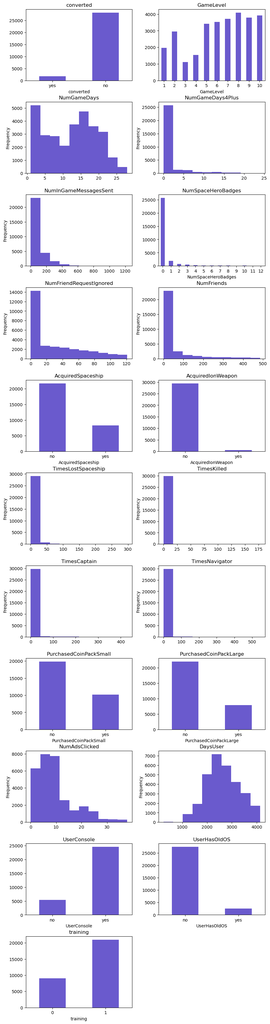

```python
# Question 1.3
# Generate histograms for all numeric variables and frequency plots for non-
# numeric variables (1 point)

rsm.distr_plot(cg_organic)  # same result when using only train data
```

```python
# radiant for neural networks model
# rsm.radiant.model.mlp({"cg_organic": cg_organic},)
```

```python
# radiant for logistic regression model
# rsm.radiant.logistic({"cg_organic": cg_organic})
```